# RSV_analysis

Nitsueh Kebere and Jessica McClintock

5/10/2022

```r
setwd("/Users/jessmcc/Documents/workProjects/ZPRIME_RSV")
library(tidyverse)
library(devtools)
library(phyloseq)
library(ggpubr)
library(paletteer)
```

# Read in Data

```r
otu_mat <- read_csv("data/point1pct/Assay_count_point1pct.csv")
tax_mat <- read_csv("data/point1pct/Assay_taxonomy_point1pct.csv")
samples_df <- read_csv("data/point1pct/Assay_annotation_point1pct.csv")
```

## Create Phyloseq Object

All analysis was conducted based on a phyloseq object. Changed metadata labels to be more descriptive for table and graphing purposes.

```r
OTU <- otu_mat %>%
  tibble::column_to_rownames("...1") %>%
  as.matrix() %>%
  otu_table(taxa_are_rows = TRUE)

TAX <- tax_mat %>%
  tibble::column_to_rownames("...1") %>%
  as.matrix() %>%
  tax_table()

samples <- samples_df %>%
  tibble::column_to_rownames("...1") %>%
  sample_data()

samples$state[samples$state == "pos"] <- "RSV+"
samples$state[samples$state == "neg"] <- "RSV-"

samples$mother_hiv[samples$mother_hiv == 0] <- "Unexposed"
samples$mother_hiv[samples$mother_hiv == 1] <- "Exposed"

colnames(samples)[5] <- "sex"
samples$sex[samples$sex == 1] <- "Female"
samples$sex[samples$sex == 2] <- "Male"
samples$sex[samples$sex == 8] <- "Unknown"

for(sample in 1:length(samples$death_age)){
    if(samples$death_age[sample] < 29){
        samples$death_age[sample] <- 0
    }else if(samples$death_age[sample] > 28 & samples$death_age[sample] < 62){
        samples$death_age[sample] <- 1
    }else if(samples$death_age[sample] > 61 & samples$death_age[sample] < 153){
        samples$death_age[sample] <- 2
    }else{
        samples$death_age[sample] <- 4
    }
}
samples$death_age <- as.factor(samples$death_age)
zprime <- phyloseq(OTU, TAX, samples)
```

# Chi-Squared test comparing demographic information

```r
genderCounts <- table(samples_df$state, samples_df$gender)

chi_stats <- list()

chi_stats$gender <- chisq.test(samples_df$state, samples_df$gender)$p.value
chi_stats$hiv <-chisq.test(samples_df$state, samples_df$mother_hiv)$p.value
chi_stats$death_age <- chisq.test(samples_df$state, samples_df$death_age)$p.value
chi_stats$location <- chisq.test(samples_df$state, samples_df$location)$p.value
chi_stats$hospitalized <- chisq.test(samples_df$state, samples_df$hosp_duration)$p.value
print(chi_stats)
```

```
## $gender
## [1] 0.1277195
##
## $hiv
## [1] 0.2688067
##
## $death_age
## [1] 0.3693676
##
## $location
## [1] 1
##
## $hospitalized
## [1] 0.1709377
```

# Create color palette that represents 15 organisms well

Selected color palette for all graphing

```r
chosen_pal_16 <- "awtools::bpalette"
chosen_pal_5 <- "fishualize::Scarus_hoefleri"
```

# RSV Status

## Visualizing Relative Abundance

Relative abundances show the microbes present in each samples’ microbiome as a percentage of the whole microbiome. Percentages will differ from sample to sample even if actual counts of specific microbes are similar. Or, percentages may seem similar when the counts are actually VERY different.

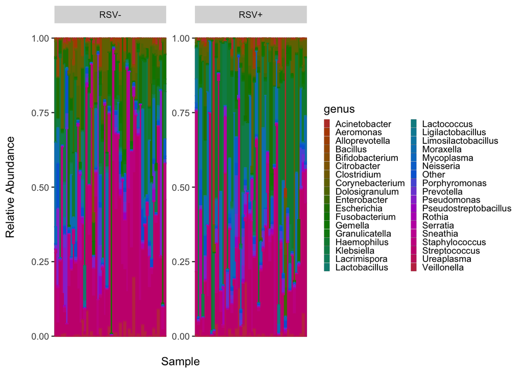

```r
relativeAbundance <- function(x){
  x / sum(x)
}

zp_rel_abund <- transform_sample_counts(zprime, relativeAbundance)

plot_bar(zp_rel_abund, fill = "genus") +
  geom_bar(aes(color = genus, fill = genus), stat = "identity", position = "stack") +
  labs(x = "Sample", y = "Relative Abundance\n") +
  facet_wrap(~state, scales = "free") +
  theme(panel.background = element_blank(),
        axis.text.x=element_blank(),
        axis.ticks.x=element_blank(),
        legend.key.size = unit(0.2, "cm")) +
  scale_color_hue(l=45) +
  scale_fill_hue(l=45)
```

```r
ggsave("Plots/point1/relativeAbundance.jpeg")
```

## Testing for a difference in genus level abundance

Analogous to a two-sample t-test, but instead we are testing whether taxa frequencies observed in both groups of metagenomic samples are equal. A Dirichlet-Multinomial distribution is assumed for the data. The HMP test null hypothesis is that there is no difference in the distribution of phyla between groups. p-values > 0.05 support the null hypothesis.

```r
zp_genus <- tax_glom(zp_rel_abund, taxrank = "genus") #relative abundance
zp_genus_counts <- tax_glom(zprime, taxrank = "genus") #absolute abundance by genus

zp_pos <- subset_samples(zp_genus_counts, state == "RSV+")
zp_neg <- subset_samples(zp_genus_counts, state =="RSV-")

zp_pos_otu <- otu_table(zp_pos) %>%
  data.frame() %>%
  t() %>%
  as.data.frame()

zp_neg_otu <- otu_table(zp_neg) %>%
  data.frame() %>%
  t() %>%
  as.data.frame()

group_data <- list(zp_pos_otu, zp_neg_otu)
(xdc <- HMP::Xdc.sevsample(group_data))
```

```
## $`Xdc statistics`
## [1] -284.5173
##
## $`p value`
## [1] 1
```